# Project 2 - Internet of Things

Viet Ba Mai, Piotr Kamoda

20 grudnia 2016

# Introduction

The goal of this phase of the project is to segment visitors of the Copernicus Center (students) into separate categories. This task will be achieved using clustering.

Given are two datasets:

- dane_obserwacyjne - information about the duration and type of interactions (activities) done by students, potentially with other ones, in relation to exhibitions of Copernicus Center.
- dane_kwestionariuszowe - information about the aforemantioned students covering their aspirations, parents job, school and grades.

# Clustering

In order to solve our problem we will implement clustering. It is a method used to separates objects that are more similar than others into groups. It is an unsupervised learning model as it does not train on given features and answers, but instead finds patterns which is a discovery rather prediction.

We will implement the following clustering methods:

- K-means
- Hierarchical clustering

# Data preparation

We will group data by student IDs and calculate aggregated measures that would help to define similarities between the pupils.

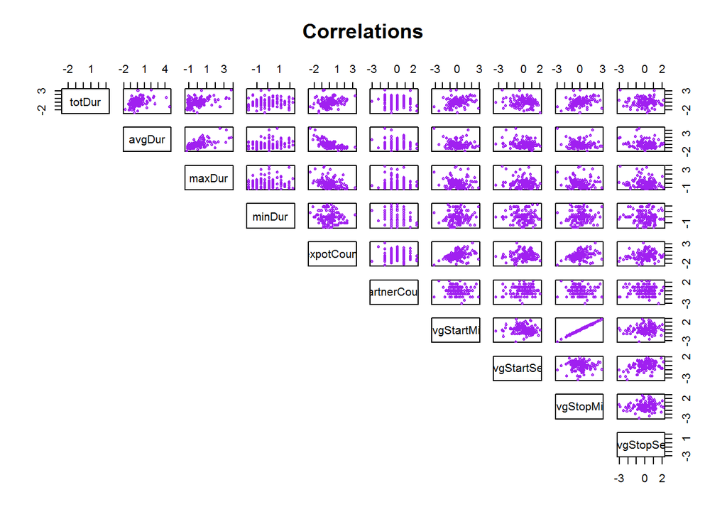

```r
schoolData <- subset(read.xlsx("dane_kwestionariuszowe.xlsx", sheetName="dane_kwestionariuszowe", encoding="UTF-8"), select = -c(Kolum1, wyk_zawod_M,   wyk_zawod_T, aspiracje))
exhibitData <- subset(read.csv("dane_obserwacyjne.csv", header=TRUE, sep=";"), select = -c(Kolumna1, lp))

#Group data by student IDs and create aggregates
exhibitData[is.na(exhibitData)] <- 0
stdData = exhibitData %>% group_by(ID) %>% summarise(totDur = sum(czas_w_sek), avgDur = mean(czas_w_sek), maxDur = max(czas_w_sek), minDur = min(czas_w_sek), expotCount = n_distinct(ekspot), partnerCount = n_distinct(ILE_OSTOW), avgStartMin = mean(start_min), avgStartSec = mean(start_s), avgStopMin = mean(stop_min), avgStopSec = mean(stop_s))
stdData$ID <- factor(stdData$ID)

#Scaling data
data <- transform(stdData,
                        totDur = as.numeric(totDur),
                        avgDur = as.numeric(avgDur),
                        maxDur = as.numeric(maxDur),
                        minDur = as.numeric(minDur),
                        expotCount = as.numeric(expotCount),
                        partnerCount = as.numeric(partnerCount),
                        avgStartMin = as.numeric(avgStartMin),
                        avgStartSec = as.numeric(avgStartSec),
                        avgStopMin = as.numeric(avgStopMin),
                        avgStopSec = as.numeric(avgStopSec))
data$totDur <- scale(data$totDur)
data$avgDur <- scale(data$avgDur)
data$maxDur <- scale(data$maxDur)
data$minDur <- scale(data$minDur)
data$expotCount <- scale(data$expotCount)
data$partnerCount <- scale(data$partnerCount)
data$avgStartMin <- scale(data$avgStartMin)
data$avgStartSec <- scale(data$avgStartSec)
data$avgStopMin <- scale(data$avgStopMin)
data$avgStopSec <- scale(data$avgStopSec)

pairs(subset(data, select=-c(ID)), main="Correlations", col = "purple", lower.panel = NULL, cex.labels=1, pch=5, cex = 0.3)
```

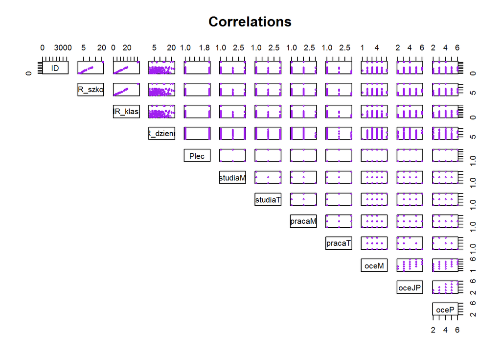

```r
pairs(schoolData, main="Correlations", col = "purple", lower.panel = NULL, cex.labels=1, pch=5, cex = 0.3)
```

The 2nd dataset (schoolData) contains only categorical data, such as flag on parents work/study status or school number and each observation describes a single student so we cannot aggregate the data by student IDs.

Discrete variables are not recommended for clustering even after scaling. The reason is that they yield too little discrimination of similarities, which is the goal to find in clustering. Hence we decided to exclude this dataset from analysis.

School data could be used when clustering for example by school, where we could create aggregates for each.

# K-means

This is the most popular clustering method which is of partitioning nature. One must define the exact number of desired clusters.

At first we find k-centers and then associate points to the nearest center.

## Three clusters

```r
set.seed(4)
k = 3
kmeans <- kmeans(subset(data, select=-c(ID)), k)
data$cluster <- factor(kmeans$cluster)
centers <- data.frame(kmeans$centers)
centers
```

```
##       totDur     avgDur     maxDur     minDur expotCount partnerCount
## 1 -0.8152637 -0.2668629 -0.2283917 -0.4460667 -0.4385539   0.37314216
## 2  0.6525319  1.1096838  0.8547020  0.4774328 -0.6757929  -0.37258189
## 3  0.1990727 -0.5322291 -0.3921633  0.0286522  0.7916261  -0.04183376
##   avgStartMin avgStartSec avgStopMin  avgStopSec
## 1  -0.7124895  0.38911289 -0.7284071 -0.02022038
## 2  -0.3035980 -0.52717120 -0.2565220 -0.48594562
## 3   0.7565571  0.04880411  0.7375535  0.33969070
```

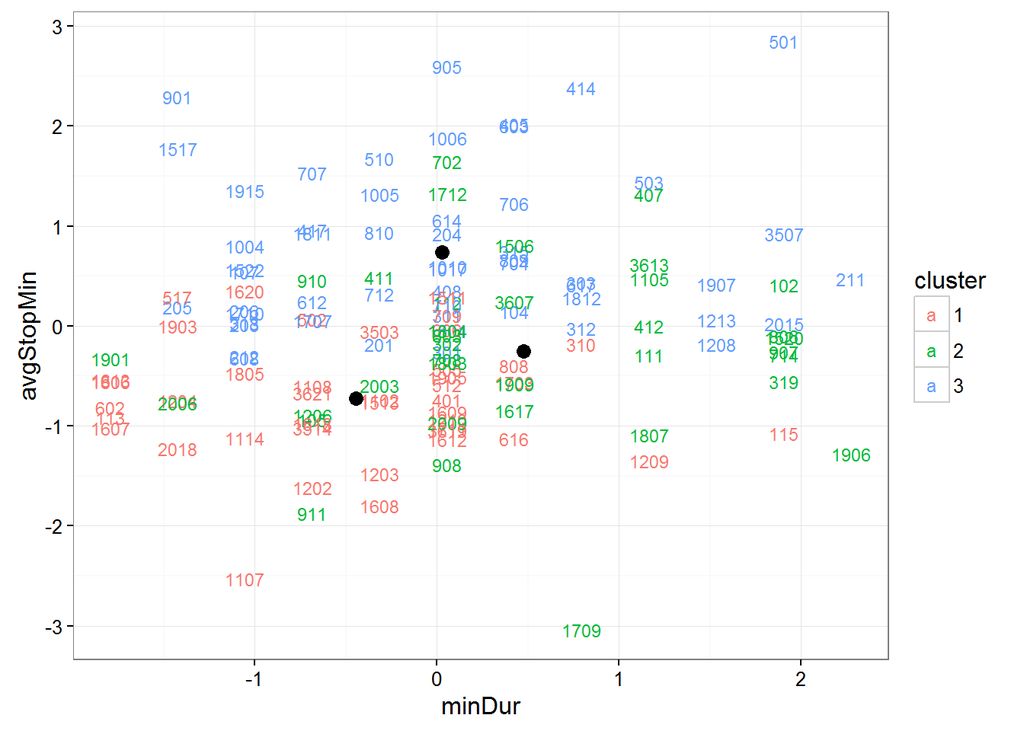

```r
ggplot(data, aes(minDur, avgStopMin)) +
  geom_text(size=3, aes(label=ID, color=cluster)) +
  geom_point(data=centers, size=3)+
  theme_bw()
```

Clustering on all variables did not yield good result, hence we tried other combinations.

```r
kmeans <- kmeans(data[,c("totDur", "expotCount", "avgStopSec")], k)
data$cluster <- factor(kmeans$cluster)
centers <- data.frame(kmeans$centers)
centers
```

```
##       totDur expotCount avgStopSec
## 1  0.8644205 -0.1961979 -0.9212893
## 2  0.2643228  0.6700821  0.6577197
## 3 -0.9244247 -0.6987213 -0.1838297
```

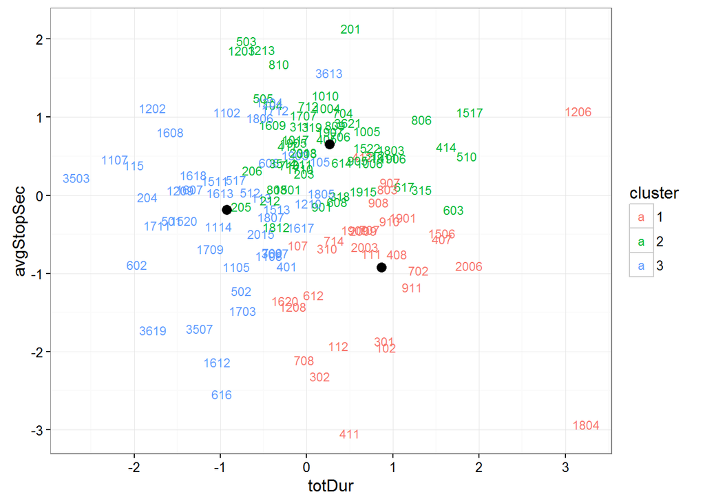

```r
ggplot(data, aes(totDur, avgStopSec)) +
  geom_text(size=3, aes(label=ID, color=cluster)) +
  geom_point(data=centers, size=3)+
  theme_bw()
```

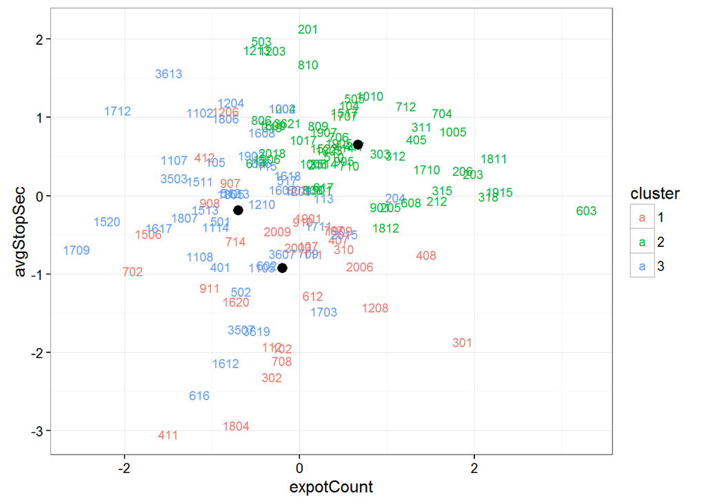

```r
ggplot(data, aes(expotCount, avgStopSec)) +
  geom_text(size=3, aes(label=ID, color=cluster)) +
  geom_point(data=centers, size=3)+
  theme_bw()
```

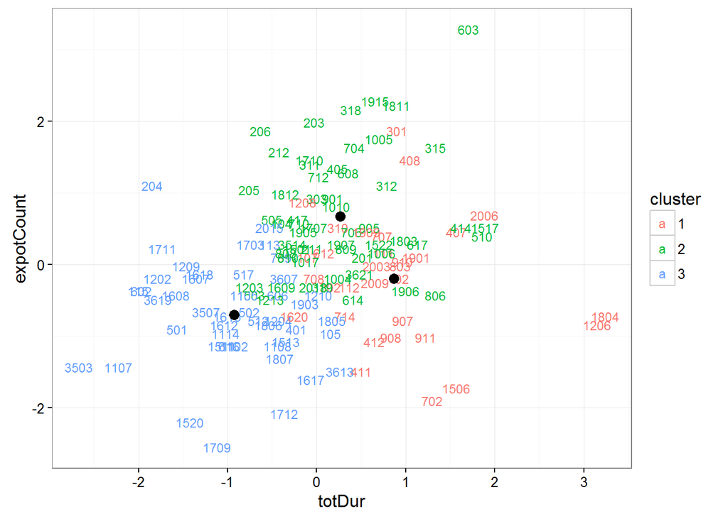

```r
ggplot(data, aes(totDur, expotCount)) +
  geom_text(size=3, aes(label=ID, color=cluster)) +
  geom_point(data=centers, size=3)+
  theme_bw()
```

```r
kmeans <- kmeans(data[,c("maxDur", "partnerCount", "avgStartSec")], k)
data$cluster <- factor(kmeans$cluster)
centers <- data.frame(kmeans$centers)
centers
```

```
##       maxDur partnerCount avgStartSec
## 1 -0.3700573    0.9978993  -0.2195494
## 2  0.1814338   -0.2588464   0.5977531
## 3  0.1712100   -1.1228612  -1.3048295
```

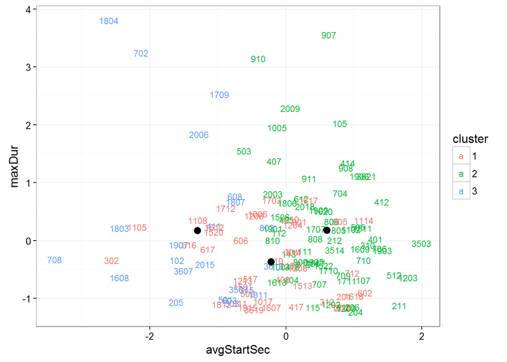

```r
ggplot(data, aes(avgStartSec, maxDur)) +
  geom_text(size=3, aes(label=ID, color=cluster)) +
  geom_point(data=centers, size=3)+
  theme_bw()
```

```r
kmeans <- kmeans(data[,c("maxDur", "minDur", "avgDur", "totDur")], k)
data$cluster <- factor(kmeans$cluster)
centers <- data.frame(kmeans$centers)
centers
```

```
##        maxDur     minDur     avgDur     totDur
## 1  0.02420118 -0.4633463 -0.1218452  0.5153706
## 2 -0.59290312  0.0281351 -0.5925698 -0.8090142
## 3  1.11723717  0.8371425  1.3978575  0.5954993
```

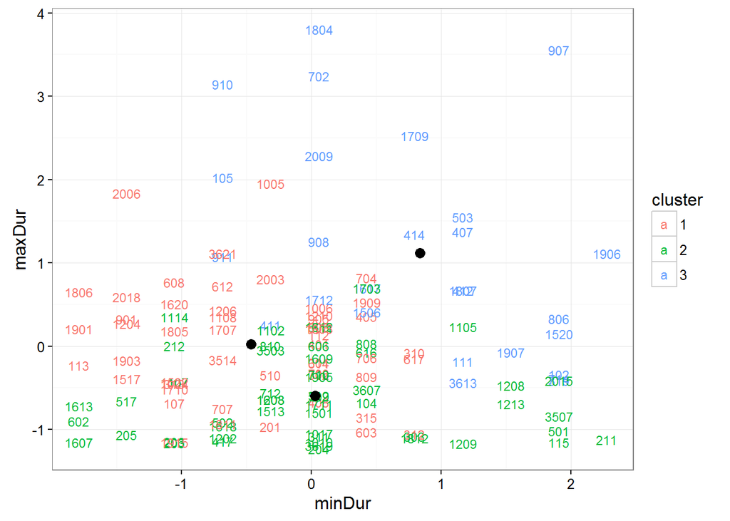

```r
ggplot(data, aes(minDur, maxDur)) +
  geom_text(size=3, aes(label=ID, color=cluster)) +
  geom_point(data=centers, size=3)+
  theme_bw()
```

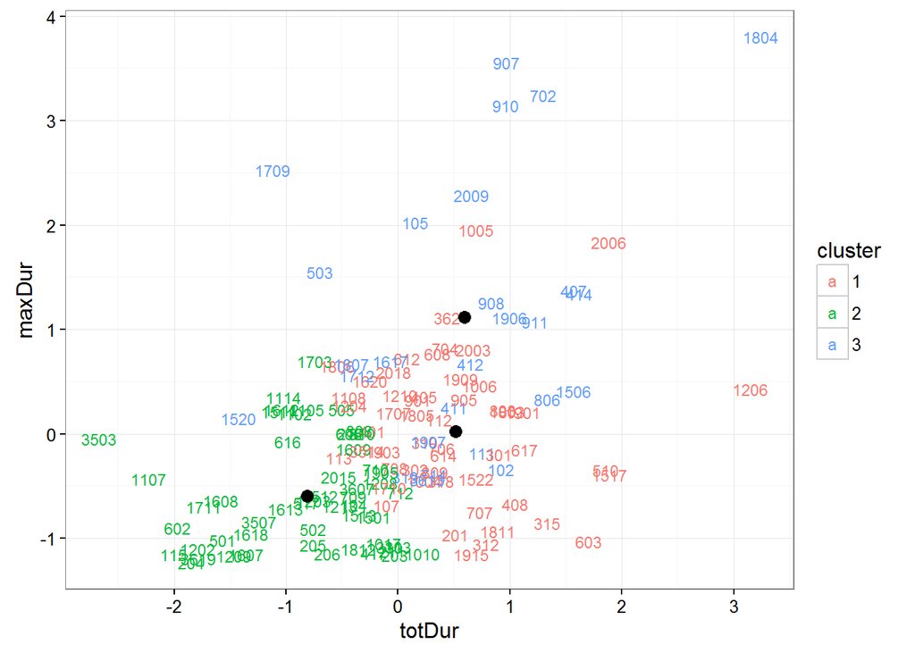

```r
ggplot(data, aes(totDur, maxDur)) +
  geom_text(size=3, aes(label=ID, color=cluster)) +
  geom_point(data=centers, size=3)+
  theme_bw()
```

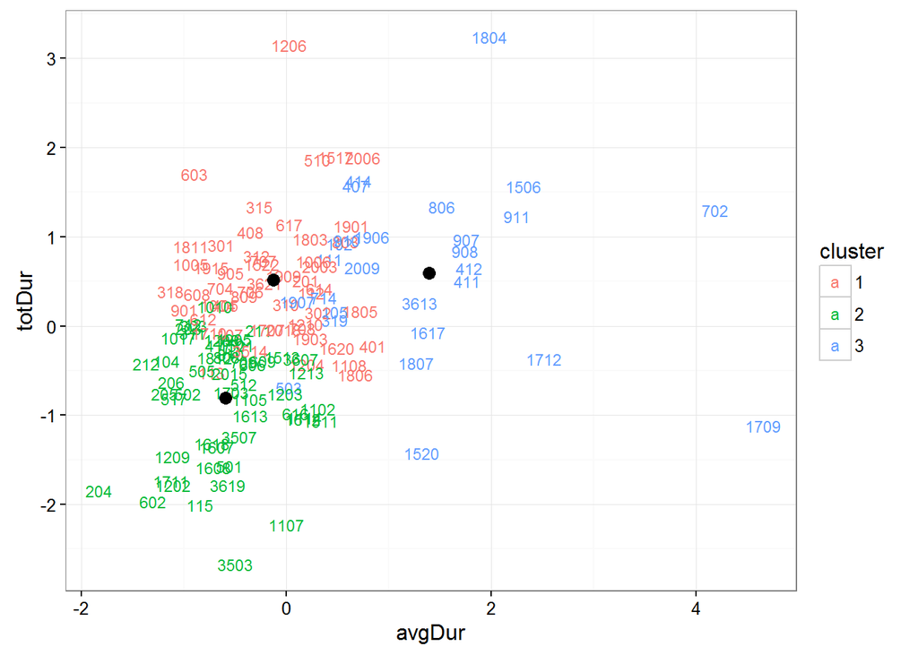

```r
ggplot(data, aes(avgDur, totDur)) +
  geom_text(size=3, aes(label=ID, color=cluster)) +
  geom_point(data=centers, size=3)+
  theme_bw()
```

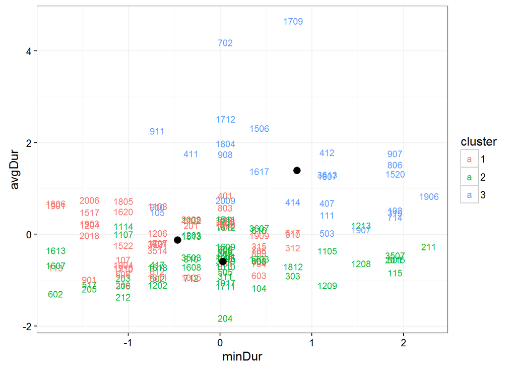

```r
ggplot(data, aes(minDur, avgDur)) +
  geom_text(size=3, aes(label=ID, color=cluster)) +
  geom_point(data=centers, size=3)+
  theme_bw()
```

```r
kmeans <- kmeans(data[,c("avgDur", "expotCount")], k)
data$cluster <- factor(kmeans$cluster)
centers <- data.frame(kmeans$centers)
centers
```

```
##        avgDur expotCount
## 1 -0.08404259 -0.2177456
## 2  2.11820802 -1.4285003
## 3 -0.84059905  1.3996246
```

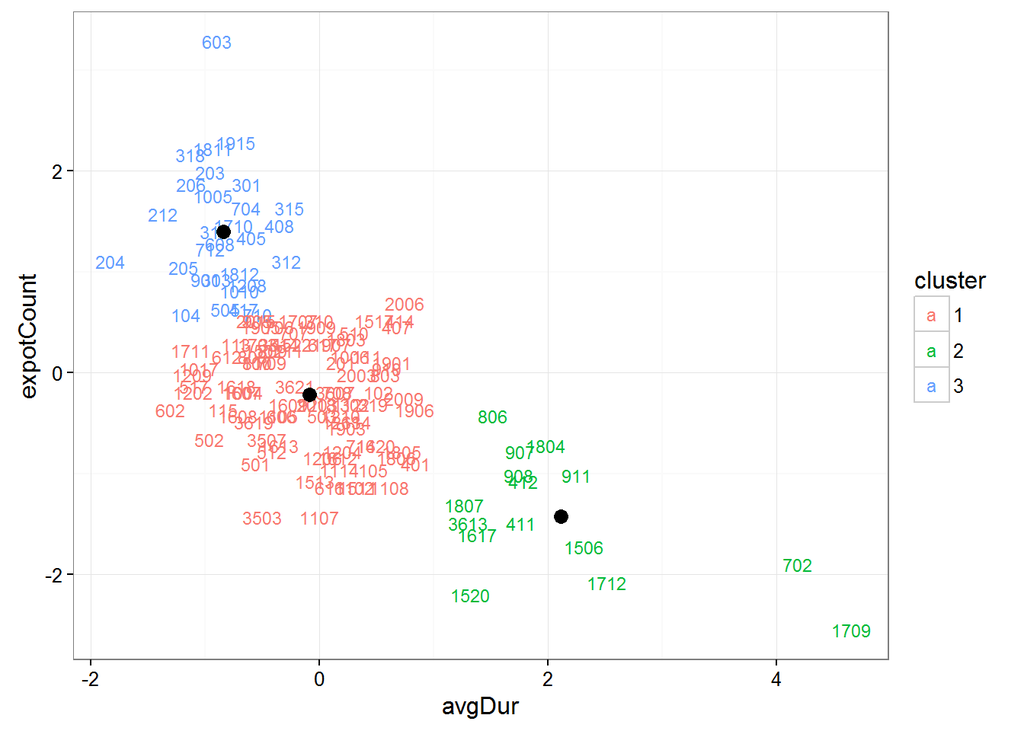

```r
ggplot(data, aes(avgDur, expotCount)) +
  geom_text(size=3, aes(label=ID, color=cluster)) +
  geom_point(data=centers, size=3)+
  theme_bw()
```

## Five clusters

```r
set.seed(4)
k = 5

kmeans <- kmeans(data[,c("totDur", "expotCount", "avgStopSec")], k)
data$cluster <- factor(kmeans$cluster)
centers <- data.frame(kmeans$centers)
centers
```

```
##        totDur  expotCount  avgStopSec
## 1 -1.28291318 -0.82810315  0.08717687
## 2  0.33052858  1.60930725  0.16210330
## 3  1.24607469 -0.23796923 -0.16619774
## 4 -0.06825468 -0.05247623  0.83571318
## 5 -0.34546845 -0.32561337 -1.45875301
```

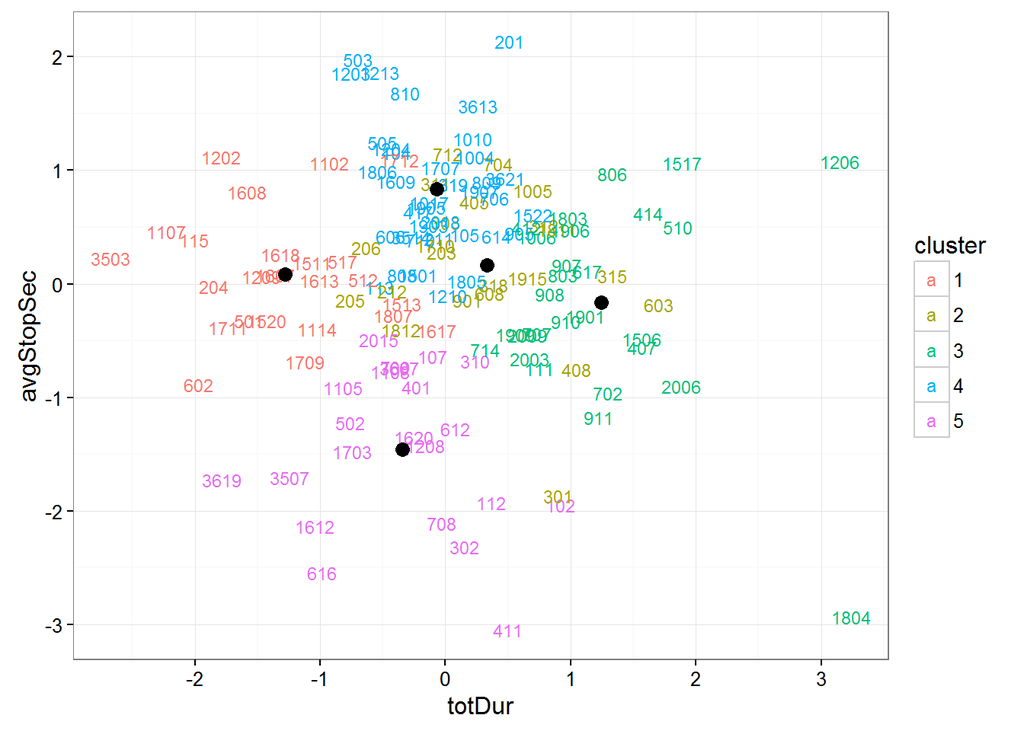

```r
ggplot(data, aes(totDur, avgStopSec)) +
  geom_text(size=3, aes(label=ID, color=cluster)) +
  geom_point(data=centers, size=3)+
  theme_bw()
```

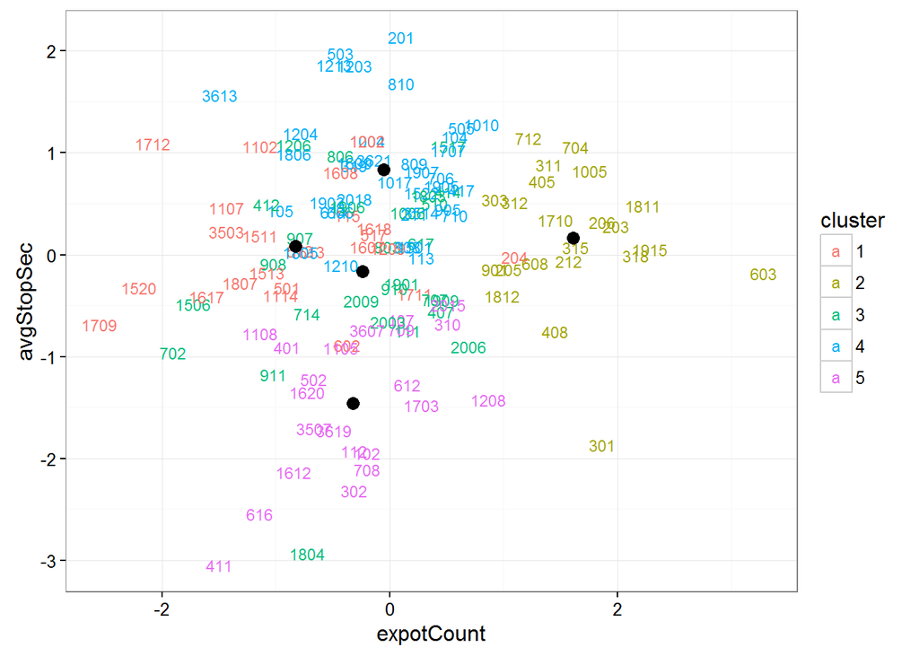

```r
ggplot(data, aes(expotCount, avgStopSec)) +
  geom_text(size=3, aes(label=ID, color=cluster)) +
  geom_point(data=centers, size=3)+
  theme_bw()
```

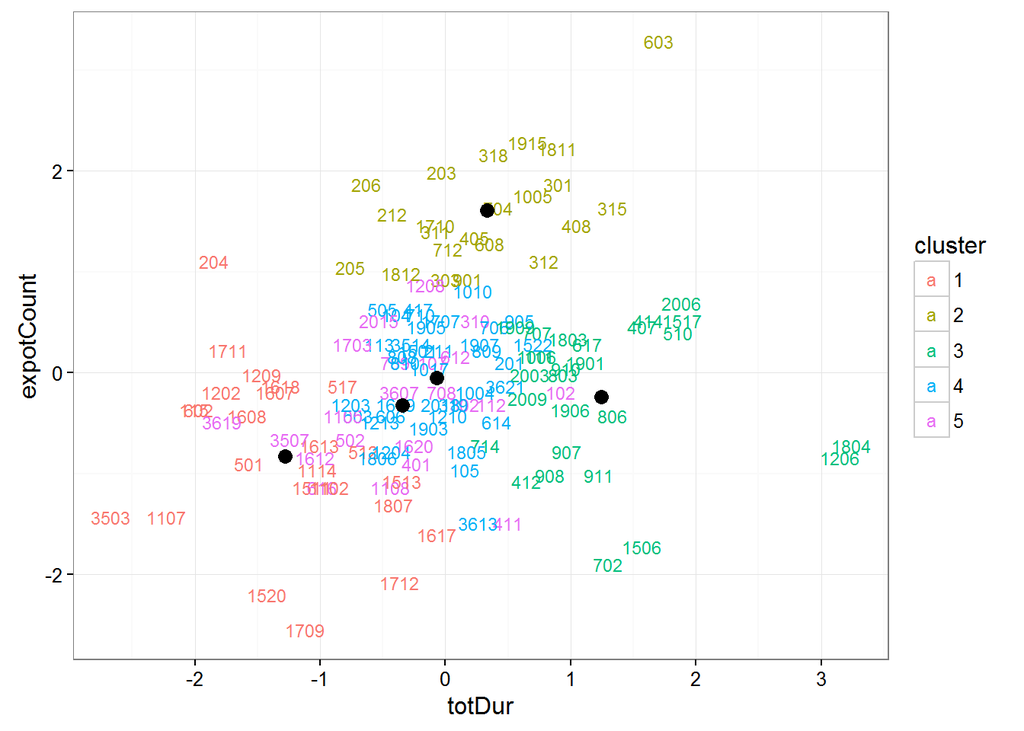

```r
ggplot(data, aes(totDur, expotCount)) +
  geom_text(size=3, aes(label=ID, color=cluster)) +
  geom_point(data=centers, size=3)+
  theme_bw()
```

```r
kmeans <- kmeans(data[,c("avgDur", "expotCount")], k)
data$cluster <- factor(kmeans$cluster)
centers <- data.frame(kmeans$centers)
centers
```

```
##       avgDur expotCount
## 1  0.1157248 -0.7937105
## 2 -0.6448953  0.1518979
## 3  0.3908819  0.1122897
## 4  2.1182080 -1.4285003
## 5 -0.8637388  1.5872851
```

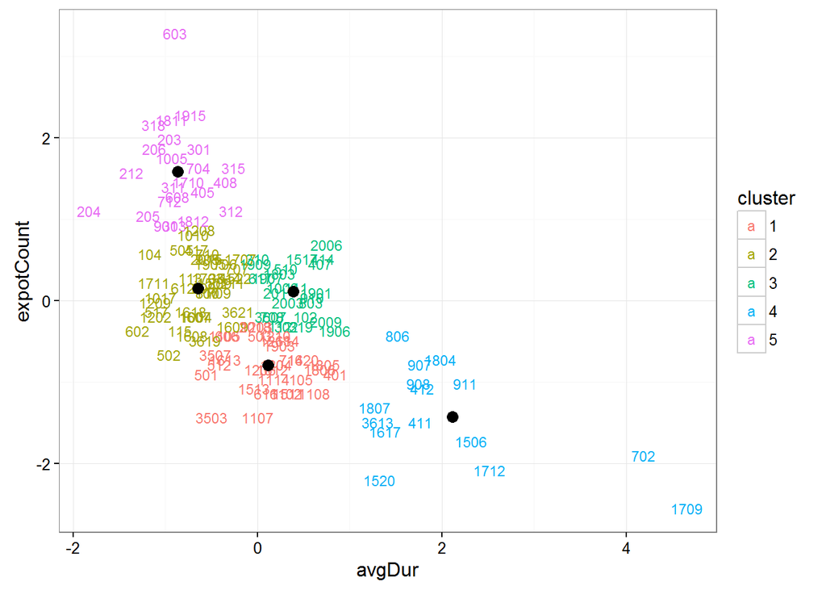

```r
ggplot(data, aes(avgDur, expotCount)) +
  geom_text(size=3, aes(label=ID, color=cluster)) +
  geom_point(data=centers, size=3)+
  theme_bw()
```

# Hierarchical Clustering

This is a cluster analysis methods which is based on creating a hierarchy of clusters. There are two approaches:

- Bottom Up (Agglomerative) where we begin with clusters for each observation and then merge pairs of clusters and lift it in the hierarchy. We will implement this method.
- Top Down (Divisive) where we start with one cluster for all observations and then recursively split them to drop them in hierarchy.

We will test several linkage criterias:

- Ward: decreases the total variance within a cluster
- Average: distance between two clusters is defined by the mean distance between a pair of observations from each.
- Single: distance between two clusters is defined by the minimum distance between a pair of observations from each.

## Three Clusters

```r
k = 3
#1st approach
distances <- dist(scale(data[,c("avgDur", "expotCount")]), method="manhattan")
as.matrix(distances)[1:10,1:7]
```

```
##            1         2         3         4         5         6         7
## 1  0.0000000 2.4560083 0.8105707 1.3642346 0.4532289 0.3883461 1.7180497
## 2  2.4560083 0.0000000 3.1783664 1.0917737 2.0027794 2.3034974 0.7379586
## 3  0.8105707 3.1783664 0.0000000 2.0865927 1.1755870 0.8748690 2.4404078
## 4  1.3642346 1.0917737 2.0865927 0.0000000 1.0289233 1.2117237 0.3538151
## 5  0.4532289 2.0027794 1.1755870 1.0289233 0.0000000 0.6426228 1.2648208
## 6  0.3883461 2.3034974 0.8748690 1.2117237 0.6426228 0.0000000 1.5655388
## 7  1.7180497 0.7379586 2.4404078 0.3538151 1.2648208 1.5655388 0.0000000
## 8  1.5377863 1.2719748 1.9063916 0.7631397 1.7920630 1.1494402 0.7630774
## 9  0.6199474 1.8360609 1.3423055 0.7442872 0.2846361 0.4674365 1.0981023
## 10 3.6556825 1.6303483 4.3780405 2.2914479 3.2024536 3.5031715 1.9376327
```

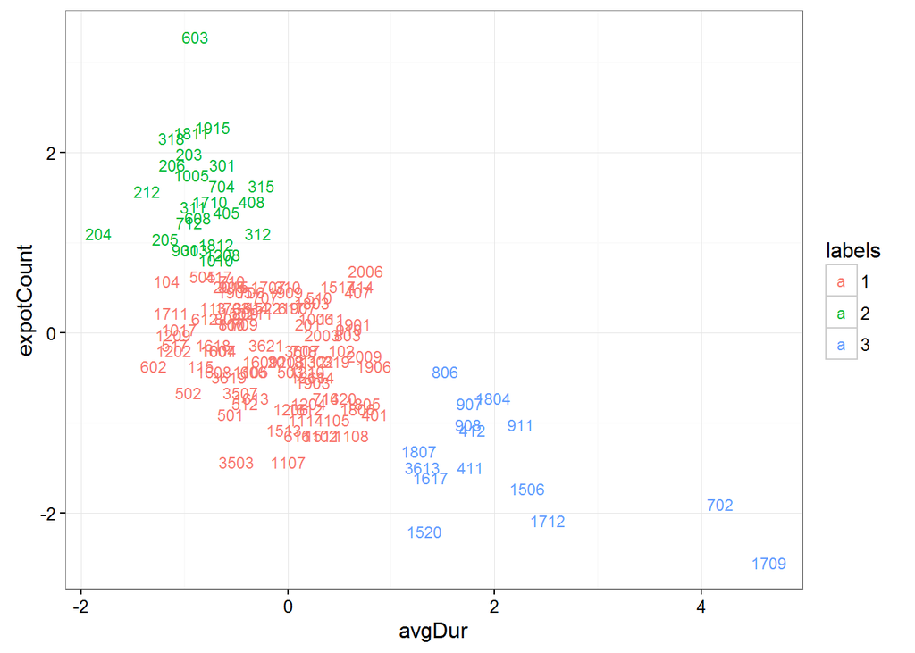

```r
hc <- hclust(distances, method="ward.D")


data$labels = factor(cutree(hc, k=k))
ggplot(data, aes(avgDur, expotCount, label=ID, color=labels)) +
  geom_text(size=3) +
  theme_bw()
```

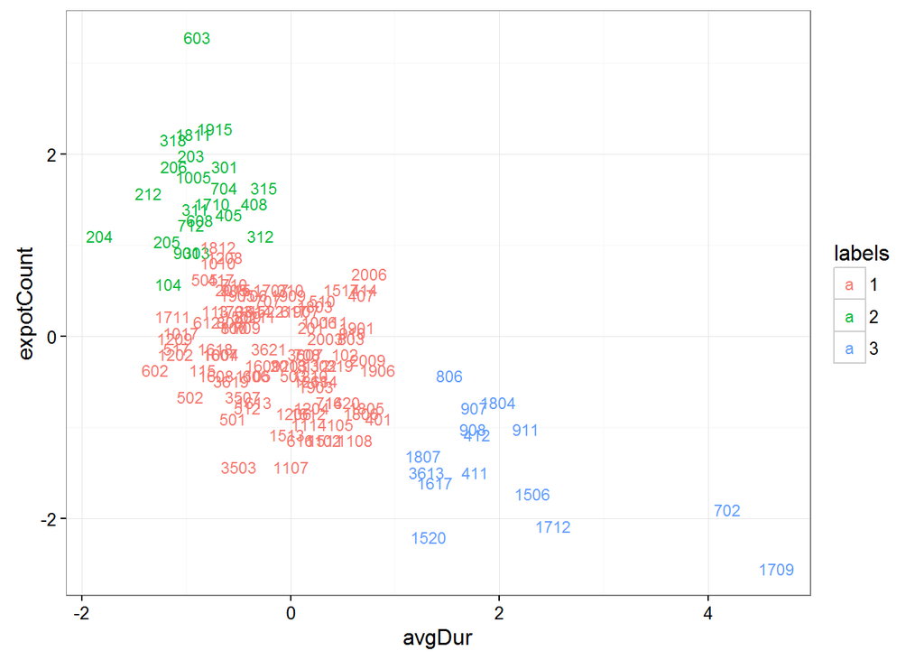

```r
#2nd approach
rownames(data) <- data$ID
dat <- scale(data[,c("avgDur", "expotCount")])

hc <- agnes(dat, method="ward")
data$labels = factor(cutree(hc, k=k))
ggplot(data, aes(avgDur, expotCount, label=ID, color=labels)) +
  geom_text(size=3) +
  theme_bw()
```

We will proceed only with the 2nd approach using different linkage methods.

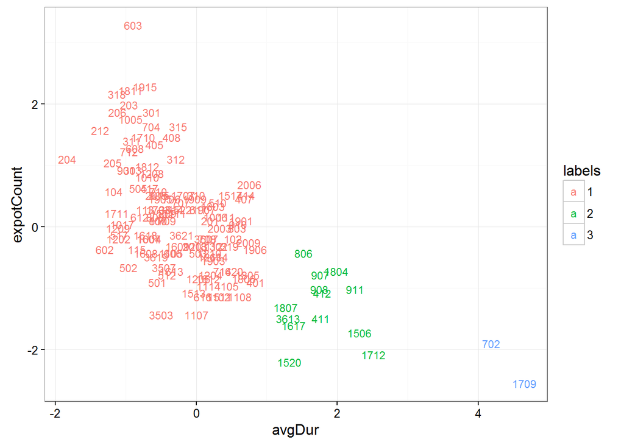

```r
hc <- agnes(dat, method="average")
data$labels = factor(cutree(hc, k=k))
ggplot(data, aes(avgDur, expotCount, label=ID, color=labels)) +
  geom_text(size=3) +
  theme_bw()
```

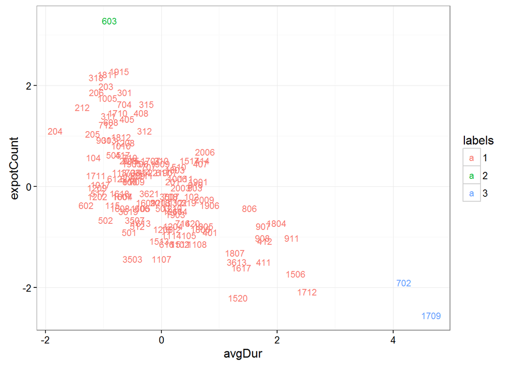

```r
hc <- agnes(dat, method="single")
data$labels = factor(cutree(hc, k=k))
ggplot(data, aes(avgDur, expotCount, label=ID, color=labels)) +
  geom_text(size=3) +
  theme_bw()
```

## Five clusters

```r
k = 5

distances <- dist(scale(data[,c("avgDur", "expotCount")]), method="manhattan")
as.matrix(distances)[1:10,1:7]
```

```
##           102       104       105       107       111       112       113
## 102 0.0000000 2.4560083 0.8105707 1.3642346 0.4532289 0.3883461 1.7180497
## 104 2.4560083 0.0000000 3.1783664 1.0917737 2.0027794 2.3034974 0.7379586
## 105 0.8105707 3.1783664 0.0000000 2.0865927 1.1755870 0.8748690 2.4404078
## 107 1.3642346 1.0917737 2.0865927 0.0000000 1.0289233 1.2117237 0.3538151
## 111 0.4532289 2.0027794 1.1755870 1.0289233 0.0000000 0.6426228 1.2648208
## 112 0.3883461 2.3034974 0.8748690 1.2117237 0.6426228 0.0000000 1.5655388
## 113 1.7180497 0.7379586 2.4404078 0.3538151 1.2648208 1.5655388 0.0000000
## 115 1.5377863 1.2719748 1.9063916 0.7631397 1.7920630 1.1494402 0.7630774
## 201 0.6199474 1.8360609 1.3423055 0.7442872 0.2846361 0.4674365 1.0981023
## 203 3.6556825 1.6303483 4.3780405 2.2914479 3.2024536 3.5031715 1.9376327
```

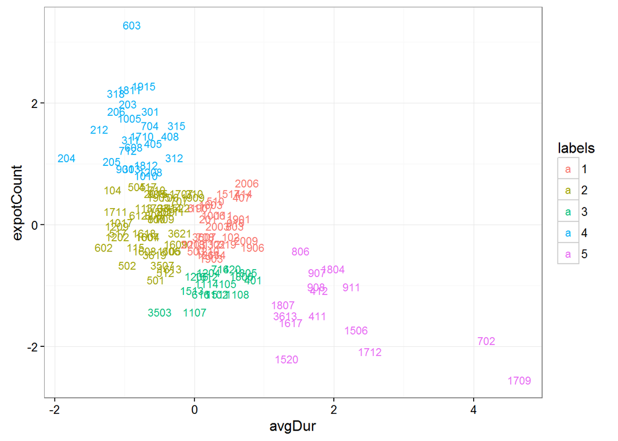

```r
hc <- hclust(distances, method="ward.D")


data$labels = factor(cutree(hc, k=k))
ggplot(data, aes(avgDur, expotCount, label=ID, color=labels)) +
  geom_text(size=3) +
  theme_bw()
```

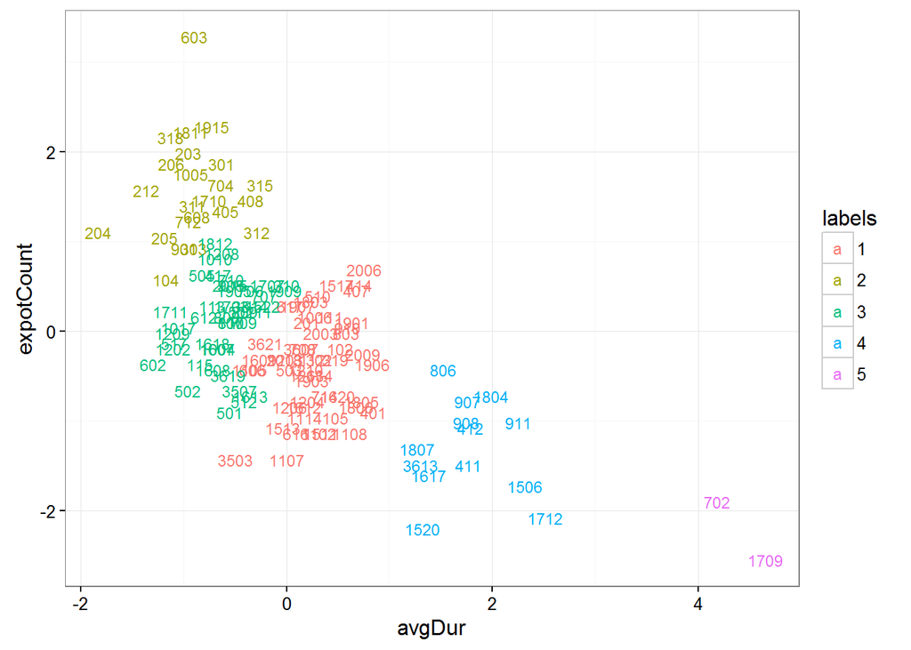

```r
rownames(data) <- data$ID
dat <- scale(data[,c("avgDur", "expotCount")])

hc <- agnes(dat, method="ward")
data$labels = factor(cutree(hc, k=k))
ggplot(data, aes(avgDur, expotCount, label=ID, color=labels)) +
  geom_text(size=3) +
  theme_bw()
```

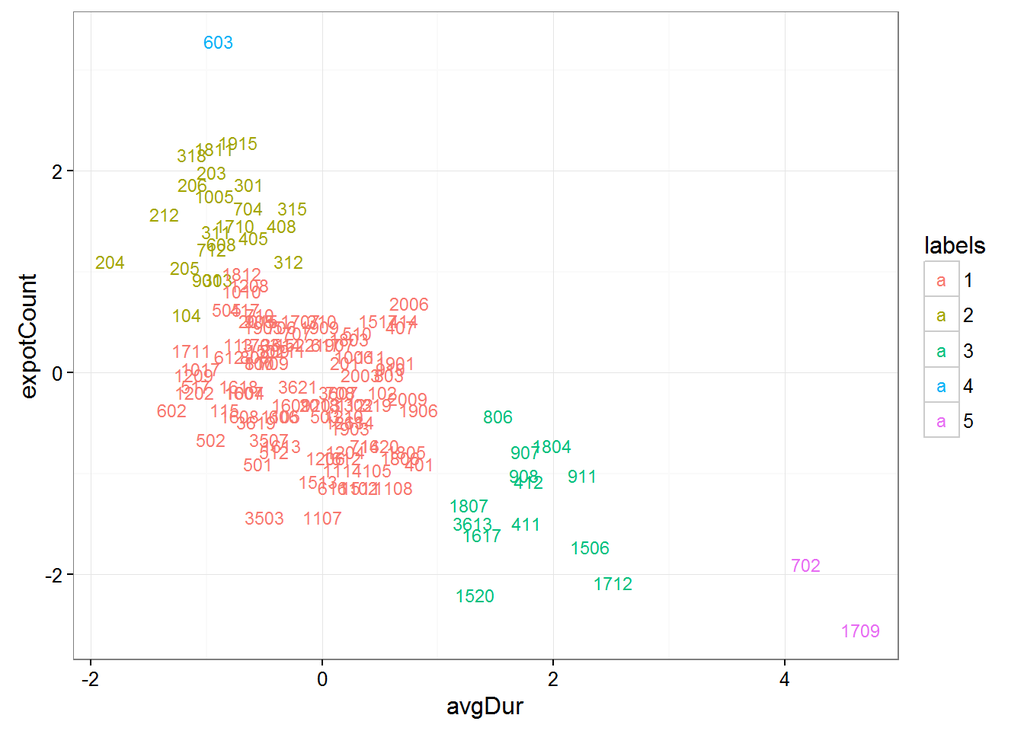

```r
hc <- agnes(dat, method="average")
data$labels = factor(cutree(hc, k=k))
ggplot(data, aes(avgDur, expotCount, label=ID, color=labels)) +
  geom_text(size=3) +
  theme_bw()
```

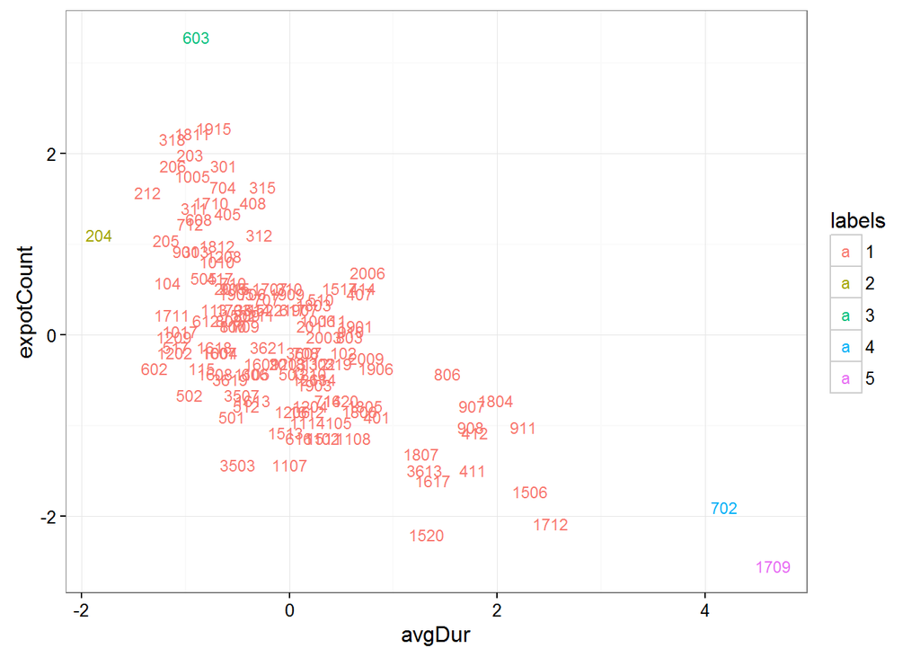

```r
hc <- agnes(dat, method="single")
data$labels = factor(cutree(hc, k=k))
ggplot(data, aes(avgDur, expotCount, label=ID, color=labels)) +
  geom_text(size=3) +
  theme_bw()
```

# Conclusions

It is obvious that the population is heterogenous. Using both k-means and hierarchical clustering we can clearly distinguish different clusters on plots, which means that points within the same group are similar.

In our analysis we could find groups by the number of exhibits interacted with and different aggregates for time and duration of visiting.